# Risk Factor Analysis

## Outcome Variable

**Outcome Variable:** wast_rec90d

## Predictor Variables

**Intervention Variable:** earlybf

**Adjustment Set:**

unadjusted

## Stratifying Variables

The analysis was stratified on these variable(s):

- agecat
- studyid
- country

## Data Summary

| agecat | studyid | country | earlybf | wast_rec90d | n_cell | n |
| --- | --- | --- | --- | --- | --- | --- |
| 0-24 months | ki0047075b-MAL-ED | BANGLADESH | 0 | 0 | 18 | 122 |
| 0-24 months | ki0047075b-MAL-ED | BANGLADESH | 0 | 1 | 32 | 122 |
| 0-24 months | ki0047075b-MAL-ED | BANGLADESH | 1 | 0 | 26 | 122 |
| 0-24 months | ki0047075b-MAL-ED | BANGLADESH | 1 | 1 | 46 | 122 |
| 0-24 months | ki0047075b-MAL-ED | BRAZIL | 0 | 0 | 3 | 23 |
| 0-24 months | ki0047075b-MAL-ED | BRAZIL | 0 | 1 | 12 | 23 |
| 0-24 months | ki0047075b-MAL-ED | BRAZIL | 1 | 0 | 3 | 23 |
| 0-24 months | ki0047075b-MAL-ED | BRAZIL | 1 | 1 | 5 | 23 |
| 0-24 months | ki0047075b-MAL-ED | INDIA | 0 | 0 | 27 | 178 |
| 0-24 months | ki0047075b-MAL-ED | INDIA | 0 | 1 | 45 | 178 |
| 0-24 months | ki0047075b-MAL-ED | INDIA | 1 | 0 | 44 | 178 |
| 0-24 months | ki0047075b-MAL-ED | INDIA | 1 | 1 | 62 | 178 |
| 0-24 months | ki0047075b-MAL-ED | NEPAL | 0 | 0 | 11 | 93 |
| 0-24 months | ki0047075b-MAL-ED | NEPAL | 0 | 1 | 40 | 93 |
| 0-24 months | ki0047075b-MAL-ED | NEPAL | 1 | 0 | 9 | 93 |
| 0-24 months | ki0047075b-MAL-ED | NEPAL | 1 | 1 | 33 | 93 |
| 0-24 months | ki0047075b-MAL-ED | PERU | 0 | 0 | 1 | 34 |
| 0-24 months | ki0047075b-MAL-ED | PERU | 0 | 1 | 3 | 34 |
| 0-24 months | ki0047075b-MAL-ED | PERU | 1 | 0 | 5 | 34 |
| 0-24 months | ki0047075b-MAL-ED | PERU | 1 | 1 | 25 | 34 |
| 0-24 months | ki0047075b-MAL-ED | SOUTH AFRICA | 0 | 0 | 6 | 80 |
| 0-24 months | ki0047075b-MAL-ED | SOUTH AFRICA | 0 | 1 | 24 | 80 |
| 0-24 months | ki0047075b-MAL-ED | SOUTH AFRICA | 1 | 0 | 8 | 80 |
| 0-24 months | ki0047075b-MAL-ED | SOUTH AFRICA | 1 | 1 | 42 | 80 |
| 0-24 months | ki0047075b-MAL-ED | TANZANIA, UNITED REPUBLIC OF | 0 | 0 | 2 | 45 |
| 0-24 months | ki0047075b-MAL-ED | TANZANIA, UNITED REPUBLIC OF | 0 | 1 | 2 | 45 |
| 0-24 months | ki0047075b-MAL-ED | TANZANIA, UNITED REPUBLIC OF | 1 | 0 | 6 | 45 |
| 0-24 months | ki0047075b-MAL-ED | TANZANIA, UNITED REPUBLIC OF | 1 | 1 | 35 | 45 |
| 0-24 months | ki1000109-EE | PAKISTAN | 0 | 0 | 127 | 257 |
| 0-24 months | ki1000109-EE | PAKISTAN | 0 | 1 | 93 | 257 |

[output cut: 138 more lines]

The following strata were considered:

- agecat: 0-24 months, studyid: ki0047075b-MAL-ED, country: BANGLADESH
- agecat: 0-24 months, studyid: ki0047075b-MAL-ED, country: BRAZIL
- agecat: 0-24 months, studyid: ki0047075b-MAL-ED, country: INDIA
- agecat: 0-24 months, studyid: ki0047075b-MAL-ED, country: NEPAL
- agecat: 0-24 months, studyid: ki0047075b-MAL-ED, country: PERU
- agecat: 0-24 months, studyid: ki0047075b-MAL-ED, country: SOUTH AFRICA
- agecat: 0-24 months, studyid: ki0047075b-MAL-ED, country: TANZANIA, UNITED REPUBLIC OF
- agecat: 0-24 months, studyid: ki1000109-EE, country: PAKISTAN
- agecat: 0-24 months, studyid: ki1000304b-SAS-CompFeed, country: INDIA
- agecat: 0-24 months, studyid: ki1017093c-NIH-Crypto, country: BANGLADESH
- agecat: 0-24 months, studyid: ki1113344-GMS-Nepal, country: NEPAL
- agecat: 0-24 months, studyid: ki1126311-ZVITAMBO, country: ZIMBABWE
- agecat: 0-24 months, studyid: kiGH5241-JiVitA-3, country: BANGLADESH
- agecat: 0-24 months, studyid: kiGH5241-JiVitA-4, country: BANGLADESH
- agecat: 0-6 months, studyid: ki0047075b-MAL-ED, country: BANGLADESH
- agecat: 0-6 months, studyid: ki0047075b-MAL-ED, country: BRAZIL
- agecat: 0-6 months, studyid: ki0047075b-MAL-ED, country: INDIA
- agecat: 0-6 months, studyid: ki0047075b-MAL-ED, country: NEPAL
- agecat: 0-6 months, studyid: ki0047075b-MAL-ED, country: PERU
- agecat: 0-6 months, studyid: ki0047075b-MAL-ED, country: SOUTH AFRICA
- agecat: 0-6 months, studyid: ki0047075b-MAL-ED, country: TANZANIA, UNITED REPUBLIC OF
- agecat: 0-6 months, studyid: ki1000109-EE, country: PAKISTAN
- agecat: 0-6 months, studyid: ki1000304b-SAS-CompFeed, country: INDIA
- agecat: 0-6 months, studyid: ki1017093c-NIH-Crypto, country: BANGLADESH
- agecat: 0-6 months, studyid: ki1113344-GMS-Nepal, country: NEPAL
- agecat: 0-6 months, studyid: ki1126311-ZVITAMBO, country: ZIMBABWE
- agecat: 0-6 months, studyid: kiGH5241-JiVitA-3, country: BANGLADESH
- agecat: 0-6 months, studyid: kiGH5241-JiVitA-4, country: BANGLADESH
- agecat: 6-24 months, studyid: ki0047075b-MAL-ED, country: BANGLADESH
- agecat: 6-24 months, studyid: ki0047075b-MAL-ED, country: BRAZIL
- agecat: 6-24 months, studyid: ki0047075b-MAL-ED, country: INDIA
- agecat: 6-24 months, studyid: ki0047075b-MAL-ED, country: NEPAL
- agecat: 6-24 months, studyid: ki0047075b-MAL-ED, country: PERU
- agecat: 6-24 months, studyid: ki0047075b-MAL-ED, country: SOUTH AFRICA
- agecat: 6-24 months, studyid: ki0047075b-MAL-ED, country: TANZANIA, UNITED REPUBLIC OF
- agecat: 6-24 months, studyid: ki1000109-EE, country: PAKISTAN
- agecat: 6-24 months, studyid: ki1000304b-SAS-CompFeed, country: INDIA
- agecat: 6-24 months, studyid: ki1017093c-NIH-Crypto, country: BANGLADESH
- agecat: 6-24 months, studyid: ki1113344-GMS-Nepal, country: NEPAL
- agecat: 6-24 months, studyid: ki1126311-ZVITAMBO, country: ZIMBABWE
- agecat: 6-24 months, studyid: kiGH5241-JiVitA-3, country: BANGLADESH
- agecat: 6-24 months, studyid: kiGH5241-JiVitA-4, country: BANGLADESH

### Dropped Strata

Some strata were dropped due to rare outcomes:

- agecat: 0-24 months, studyid: ki0047075b-MAL-ED, country: BRAZIL
- agecat: 0-24 months, studyid: ki0047075b-MAL-ED, country: PERU
- agecat: 0-24 months, studyid: ki0047075b-MAL-ED, country: TANZANIA, UNITED REPUBLIC OF
- agecat: 0-6 months, studyid: ki0047075b-MAL-ED, country: BRAZIL
- agecat: 0-6 months, studyid: ki0047075b-MAL-ED, country: NEPAL
- agecat: 0-6 months, studyid: ki0047075b-MAL-ED, country: PERU
- agecat: 0-6 months, studyid: ki0047075b-MAL-ED, country: SOUTH AFRICA
- agecat: 0-6 months, studyid: ki0047075b-MAL-ED, country: TANZANIA, UNITED REPUBLIC OF
- agecat: 6-24 months, studyid: ki0047075b-MAL-ED, country: BRAZIL
- agecat: 6-24 months, studyid: ki0047075b-MAL-ED, country: NEPAL
- agecat: 6-24 months, studyid: ki0047075b-MAL-ED, country: PERU
- agecat: 6-24 months, studyid: ki0047075b-MAL-ED, country: SOUTH AFRICA
- agecat: 6-24 months, studyid: ki0047075b-MAL-ED, country: TANZANIA, UNITED REPUBLIC OF
- agecat: 6-24 months, studyid: ki1017093c-NIH-Crypto, country: BANGLADESH
- agecat: 6-24 months, studyid: kiGH5241-JiVitA-3, country: BANGLADESH

## Methods Detail

We’re interested in the causal parameters $E[Y_a]$ for all values of $a \in \mathcal{A}$. These parameters represent the mean outcome if, possibly contrary to fact, we intervened to set all units to have $A=a$. Under the randomization and positivity assumptions, these are identified by the statistical parameters $\psi_a=E_W[E_{Y|A,W}(Y|A=a,W)]$. In addition, we’re interested in the mean of $Y$, $E[Y]$ under no intervention (the observed mean). We will estimate these parameters by using SuperLearner to fit the relevant likelihood factors – $E_{Y|A,W}(Y|A=a,W)$ and $p(A=a|W)$, and then updating our likelihood fit using a joint TMLE.

For unadjusted analyses ($W=\{\}$), initial likelihoods were estimated using Lrnr_glm to estimate the simple $E(Y|A)$ and Lrnr_mean to estimate $p(A)$. For adjusted analyses, a small library containing Lrnr_glmnet, Lrnr_xgboost, and Lrnr_mean was used.

Having estimated these parameters, we will then use the delta method to estimate relative risks and attributable risks relative to a prespecified baseline level of $A$.

# Results Detail

## Results Plots

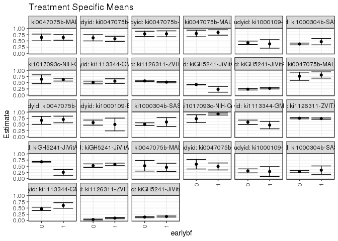

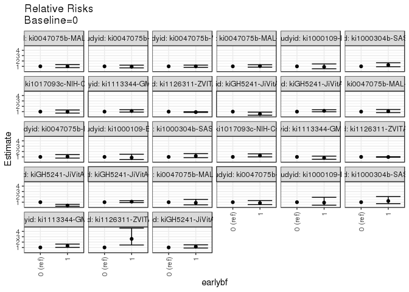

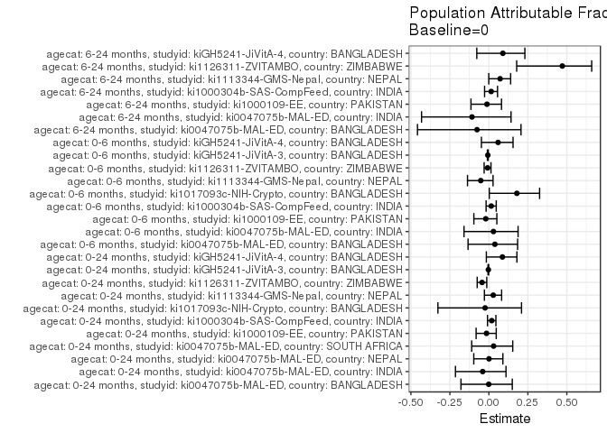

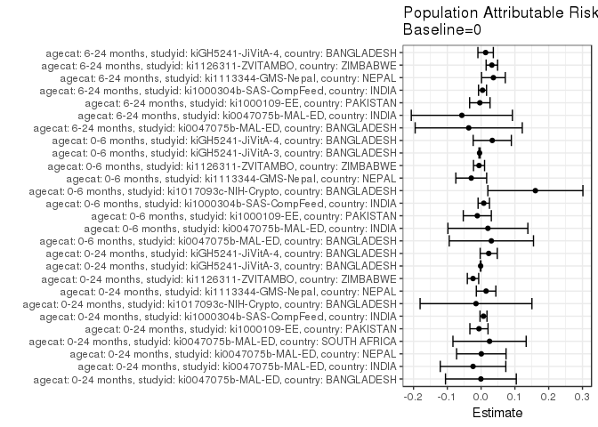

## Results Table

### Parameter: TSM

| agecat | studyid | country | intervention_level | baseline_level | estimate | ci_lower | ci_upper |
| --- | --- | --- | --- | --- | --- | --- | --- |
| 0-24 months | ki0047075b-MAL-ED | BANGLADESH | 0 | NA | 0.6400000 | 0.5033508 | 0.7766492 |
| 0-24 months | ki0047075b-MAL-ED | BANGLADESH | 1 | NA | 0.6388889 | 0.5260667 | 0.7517111 |
| 0-24 months | ki0047075b-MAL-ED | INDIA | 0 | NA | 0.6250000 | 0.4991100 | 0.7508900 |
| 0-24 months | ki0047075b-MAL-ED | INDIA | 1 | NA | 0.5849057 | 0.4818334 | 0.6879779 |
| 0-24 months | ki0047075b-MAL-ED | NEPAL | 0 | NA | 0.7843137 | 0.6765475 | 0.8920799 |
| 0-24 months | ki0047075b-MAL-ED | NEPAL | 1 | NA | 0.7857143 | 0.6655613 | 0.9058673 |
| 0-24 months | ki0047075b-MAL-ED | SOUTH AFRICA | 0 | NA | 0.8000000 | 0.6657395 | 0.9342605 |
| 0-24 months | ki0047075b-MAL-ED | SOUTH AFRICA | 1 | NA | 0.8400000 | 0.7318211 | 0.9481789 |
| 0-24 months | ki1000109-EE | PAKISTAN | 0 | NA | 0.4227273 | 0.3522484 | 0.4932061 |
| 0-24 months | ki1000109-EE | PAKISTAN | 1 | NA | 0.3783784 | 0.2062576 | 0.5504991 |
| 0-24 months | ki1000304b-SAS-CompFeed | INDIA | 0 | NA | 0.3756684 | 0.3390824 | 0.4122545 |
| 0-24 months | ki1000304b-SAS-CompFeed | INDIA | 1 | NA | 0.4677419 | 0.3388388 | 0.5966451 |
| 0-24 months | ki1017093c-NIH-Crypto | BANGLADESH | 0 | NA | 0.6388889 | 0.4605429 | 0.8172349 |
| 0-24 months | ki1017093c-NIH-Crypto | BANGLADESH | 1 | NA | 0.6218182 | 0.5653577 | 0.6782786 |
| 0-24 months | ki1113344-GMS-Nepal | NEPAL | 0 | NA | 0.5080645 | 0.4534457 | 0.5626833 |
| 0-24 months | ki1113344-GMS-Nepal | NEPAL | 1 | NA | 0.5639098 | 0.4685686 | 0.6592509 |
| 0-24 months | ki1126311-ZVITAMBO | ZIMBABWE | 0 | NA | 0.5712568 | 0.5471759 | 0.5953376 |
| 0-24 months | ki1126311-ZVITAMBO | ZIMBABWE | 1 | NA | 0.5219326 | 0.4971580 | 0.5467072 |
| 0-24 months | kiGH5241-JiVitA-3 | BANGLADESH | 0 | NA | 0.4242344 | 0.4130657 | 0.4354030 |
| 0-24 months | kiGH5241-JiVitA-3 | BANGLADESH | 1 | NA | 0.2321429 | 0.1152363 | 0.3490495 |
| 0-24 months | kiGH5241-JiVitA-4 | BANGLADESH | 0 | NA | 0.2360743 | 0.2047360 | 0.2674126 |
| 0-24 months | kiGH5241-JiVitA-4 | BANGLADESH | 1 | NA | 0.2714829 | 0.2469755 | 0.2959902 |
| 0-6 months | ki0047075b-MAL-ED | BANGLADESH | 0 | NA | 0.7600000 | 0.5939976 | 0.9260024 |
| 0-6 months | ki0047075b-MAL-ED | BANGLADESH | 1 | NA | 0.8108108 | 0.6847315 | 0.9368901 |
| 0-6 months | ki0047075b-MAL-ED | INDIA | 0 | NA | 0.6666667 | 0.5061820 | 0.8271513 |
| 0-6 months | ki0047075b-MAL-ED | INDIA | 1 | NA | 0.7021277 | 0.5683870 | 0.8358683 |
| 0-6 months | ki1000109-EE | PAKISTAN | 0 | NA | 0.5760870 | 0.4734543 | 0.6787196 |
| 0-6 months | ki1000109-EE | PAKISTAN | 1 | NA | 0.5000000 | 0.2418553 | 0.7581447 |
| 0-6 months | ki1000304b-SAS-CompFeed | INDIA | 0 | NA | 0.5114007 | 0.4550055 | 0.5677958 |
| 0-6 months | ki1000304b-SAS-CompFeed | INDIA | 1 | NA | 0.6000000 | 0.4210856 | 0.7789144 |
| 0-6 months | ki1017093c-NIH-Crypto | BANGLADESH | 0 | NA | 0.7333333 | 0.5730670 | 0.8935997 |
| 0-6 months | ki1017093c-NIH-Crypto | BANGLADESH | 1 | NA | 0.9226190 | 0.8817191 | 0.9635190 |
| 0-6 months | ki1113344-GMS-Nepal | NEPAL | 0 | NA | 0.5901639 | 0.5023101 | 0.6780178 |
| 0-6 months | ki1113344-GMS-Nepal | NEPAL | 1 | NA | 0.4761905 | 0.3248431 | 0.6275378 |
| 0-6 months | ki1126311-ZVITAMBO | ZIMBABWE | 0 | NA | 0.7522124 | 0.7282062 | 0.7762186 |
| 0-6 months | ki1126311-ZVITAMBO | ZIMBABWE | 1 | NA | 0.7387560 | 0.7121574 | 0.7653545 |
| 0-6 months | kiGH5241-JiVitA-3 | BANGLADESH | 0 | NA | 0.6810603 | 0.6677046 | 0.6944160 |
| 0-6 months | kiGH5241-JiVitA-3 | BANGLADESH | 1 | NA | 0.2549020 | 0.1352318 | 0.3745721 |
| 0-6 months | kiGH5241-JiVitA-4 | BANGLADESH | 0 | NA | 0.5257732 | 0.4554445 | 0.5961019 |
| 0-6 months | kiGH5241-JiVitA-4 | BANGLADESH | 1 | NA | 0.5766017 | 0.5254445 | 0.6277588 |
| 6-24 months | ki0047075b-MAL-ED | BANGLADESH | 0 | NA | 0.5200000 | 0.3060179 | 0.7339821 |
| 6-24 months | ki0047075b-MAL-ED | BANGLADESH | 1 | NA | 0.4571429 | 0.2911813 | 0.6231045 |
| 6-24 months | ki0047075b-MAL-ED | INDIA | 0 | NA | 0.5833333 | 0.3895024 | 0.7771642 |
| 6-24 months | ki0047075b-MAL-ED | INDIA | 1 | NA | 0.4915254 | 0.3502250 | 0.6328259 |
| 6-24 months | ki1000109-EE | PAKISTAN | 0 | NA | 0.3125000 | 0.2313361 | 0.3936639 |
| 6-24 months | ki1000109-EE | PAKISTAN | 1 | NA | 0.2857143 | 0.0885683 | 0.4828603 |
| 6-24 months | ki1000304b-SAS-CompFeed | INDIA | 0 | NA | 0.2811791 | 0.2380893 | 0.3242689 |
| 6-24 months | ki1000304b-SAS-CompFeed | INDIA | 1 | NA | 0.3437500 | 0.1745725 | 0.5129275 |
| 6-24 months | ki1113344-GMS-Nepal | NEPAL | 0 | NA | 0.4680000 | 0.4004392 | 0.5355608 |
| 6-24 months | ki1113344-GMS-Nepal | NEPAL | 1 | NA | 0.6043956 | 0.4936075 | 0.7151837 |
| 6-24 months | ki1126311-ZVITAMBO | ZIMBABWE | 0 | NA | 0.0357143 | 0.0174526 | 0.0539760 |
| 6-24 months | ki1126311-ZVITAMBO | ZIMBABWE | 1 | NA | 0.0928030 | 0.0685822 | 0.1170238 |
| 6-24 months | kiGH5241-JiVitA-4 | BANGLADESH | 0 | NA | 0.1357143 | 0.1071560 | 0.1642725 |
| 6-24 months | kiGH5241-JiVitA-4 | BANGLADESH | 1 | NA | 0.1569038 | 0.1345932 | 0.1792143 |

### Parameter: E(Y)

| agecat | studyid | country | intervention_level | baseline_level | estimate | ci_lower | ci_upper |
| --- | --- | --- | --- | --- | --- | --- | --- |
| 0-24 months | ki0047075b-MAL-ED | BANGLADESH | NA | NA | 0.6393443 | 0.5524803 | 0.7262082 |
| 0-24 months | ki0047075b-MAL-ED | INDIA | NA | NA | 0.6011236 | 0.5212729 | 0.6809743 |
| 0-24 months | ki0047075b-MAL-ED | NEPAL | NA | NA | 0.7849462 | 0.7049947 | 0.8648978 |
| 0-24 months | ki0047075b-MAL-ED | SOUTH AFRICA | NA | NA | 0.8250000 | 0.7407860 | 0.9092140 |
| 0-24 months | ki1000109-EE | PAKISTAN | NA | NA | 0.4163424 | 0.3511349 | 0.4815500 |
| 0-24 months | ki1000304b-SAS-CompFeed | INDIA | NA | NA | 0.3827160 | 0.3474971 | 0.4179350 |
| 0-24 months | ki1017093c-NIH-Crypto | BANGLADESH | NA | NA | 0.6237942 | 0.5698223 | 0.6777662 |
| 0-24 months | ki1113344-GMS-Nepal | NEPAL | NA | NA | 0.5227723 | 0.4753649 | 0.5701796 |
| 0-24 months | ki1126311-ZVITAMBO | ZIMBABWE | NA | NA | 0.5472806 | 0.5299898 | 0.5645714 |
| 0-24 months | kiGH5241-JiVitA-3 | BANGLADESH | NA | NA | 0.4228126 | 0.4116855 | 0.4339397 |
| 0-24 months | kiGH5241-JiVitA-4 | BANGLADESH | NA | NA | 0.2585790 | 0.2392503 | 0.2779077 |
| 0-6 months | ki0047075b-MAL-ED | BANGLADESH | NA | NA | 0.7903226 | 0.6894772 | 0.8911679 |
| 0-6 months | ki0047075b-MAL-ED | INDIA | NA | NA | 0.6867470 | 0.5837430 | 0.7897510 |
| 0-6 months | ki1000109-EE | PAKISTAN | NA | NA | 0.5648148 | 0.4692893 | 0.6603404 |
| 0-6 months | ki1000304b-SAS-CompFeed | INDIA | NA | NA | 0.5192878 | 0.4654446 | 0.5731311 |
| 0-6 months | ki1017093c-NIH-Crypto | BANGLADESH | NA | NA | 0.8939394 | 0.8505280 | 0.9373508 |
| 0-6 months | ki1113344-GMS-Nepal | NEPAL | NA | NA | 0.5609756 | 0.4845156 | 0.6374356 |
| 0-6 months | ki1126311-ZVITAMBO | ZIMBABWE | NA | NA | 0.7460664 | 0.7282412 | 0.7638917 |
| 0-6 months | kiGH5241-JiVitA-3 | BANGLADESH | NA | NA | 0.6764644 | 0.6631306 | 0.6897982 |
| 0-6 months | kiGH5241-JiVitA-4 | BANGLADESH | NA | NA | 0.5587703 | 0.5173487 | 0.6001920 |
| 6-24 months | ki0047075b-MAL-ED | BANGLADESH | NA | NA | 0.4833333 | 0.3508378 | 0.6158289 |
| 6-24 months | ki0047075b-MAL-ED | INDIA | NA | NA | 0.5263158 | 0.4116286 | 0.6410029 |
| 6-24 months | ki1000109-EE | PAKISTAN | NA | NA | 0.3087248 | 0.2336906 | 0.3837591 |
| 6-24 months | ki1000304b-SAS-CompFeed | INDIA | NA | NA | 0.2854123 | 0.2436284 | 0.3271961 |
| 6-24 months | ki1113344-GMS-Nepal | NEPAL | NA | NA | 0.5043988 | 0.4461732 | 0.5626244 |
| 6-24 months | ki1126311-ZVITAMBO | ZIMBABWE | NA | NA | 0.0675105 | 0.0516864 | 0.0833347 |
| 6-24 months | kiGH5241-JiVitA-4 | BANGLADESH | NA | NA | 0.1490765 | 0.1314900 | 0.1666630 |

### Parameter: RR

| agecat | studyid | country | intervention_level | baseline_level | estimate | ci_lower | ci_upper |
| --- | --- | --- | --- | --- | --- | --- | --- |
| 0-24 months | ki0047075b-MAL-ED | BANGLADESH | 0 | 0 | 1.0000000 | 1.0000000 | 1.0000000 |
| 0-24 months | ki0047075b-MAL-ED | BANGLADESH | 1 | 0 | 0.9982639 | 0.7563394 | 1.3175709 |
| 0-24 months | ki0047075b-MAL-ED | INDIA | 0 | 0 | 1.0000000 | 1.0000000 | 1.0000000 |
| 0-24 months | ki0047075b-MAL-ED | INDIA | 1 | 0 | 0.9358491 | 0.7160967 | 1.2230380 |
| 0-24 months | ki0047075b-MAL-ED | NEPAL | 0 | 0 | 1.0000000 | 1.0000000 | 1.0000000 |
| 0-24 months | ki0047075b-MAL-ED | NEPAL | 1 | 0 | 1.0017857 | 0.8150417 | 1.2313168 |
| 0-24 months | ki0047075b-MAL-ED | SOUTH AFRICA | 0 | 0 | 1.0000000 | 1.0000000 | 1.0000000 |
| 0-24 months | ki0047075b-MAL-ED | SOUTH AFRICA | 1 | 0 | 1.0500000 | 0.8496502 | 1.2975928 |
| 0-24 months | ki1000109-EE | PAKISTAN | 0 | 0 | 1.0000000 | 1.0000000 | 1.0000000 |
| 0-24 months | ki1000109-EE | PAKISTAN | 1 | 0 | 0.8950886 | 0.5514365 | 1.4529028 |
| 0-24 months | ki1000304b-SAS-CompFeed | INDIA | 0 | 0 | 1.0000000 | 1.0000000 | 1.0000000 |
| 0-24 months | ki1000304b-SAS-CompFeed | INDIA | 1 | 0 | 1.2450924 | 0.9295004 | 1.6678370 |
| 0-24 months | ki1017093c-NIH-Crypto | BANGLADESH | 0 | 0 | 1.0000000 | 1.0000000 | 1.0000000 |
| 0-24 months | ki1017093c-NIH-Crypto | BANGLADESH | 1 | 0 | 0.9732806 | 0.7255012 | 1.3056838 |
| 0-24 months | ki1113344-GMS-Nepal | NEPAL | 0 | 0 | 1.0000000 | 1.0000000 | 1.0000000 |
| 0-24 months | ki1113344-GMS-Nepal | NEPAL | 1 | 0 | 1.1099176 | 0.9083539 | 1.3562083 |
| 0-24 months | ki1126311-ZVITAMBO | ZIMBABWE | 0 | 0 | 1.0000000 | 1.0000000 | 1.0000000 |
| 0-24 months | ki1126311-ZVITAMBO | ZIMBABWE | 1 | 0 | 0.9136568 | 0.8574478 | 0.9735505 |
| 0-24 months | kiGH5241-JiVitA-3 | BANGLADESH | 0 | 0 | 1.0000000 | 1.0000000 | 1.0000000 |
| 0-24 months | kiGH5241-JiVitA-3 | BANGLADESH | 1 | 0 | 0.5472043 | 0.3304769 | 0.9060619 |
| 0-24 months | kiGH5241-JiVitA-4 | BANGLADESH | 0 | 0 | 1.0000000 | 1.0000000 | 1.0000000 |
| 0-24 months | kiGH5241-JiVitA-4 | BANGLADESH | 1 | 0 | 1.1499893 | 0.9794268 | 1.3502544 |
| 0-6 months | ki0047075b-MAL-ED | BANGLADESH | 0 | 0 | 1.0000000 | 1.0000000 | 1.0000000 |
| 0-6 months | ki0047075b-MAL-ED | BANGLADESH | 1 | 0 | 1.0668563 | 0.8159358 | 1.3949411 |
| 0-6 months | ki0047075b-MAL-ED | INDIA | 0 | 0 | 1.0000000 | 1.0000000 | 1.0000000 |
| 0-6 months | ki0047075b-MAL-ED | INDIA | 1 | 0 | 1.0531915 | 0.7747916 | 1.4316266 |
| 0-6 months | ki1000109-EE | PAKISTAN | 0 | 0 | 1.0000000 | 1.0000000 | 1.0000000 |
| 0-6 months | ki1000109-EE | PAKISTAN | 1 | 0 | 0.8679245 | 0.5026741 | 1.4985715 |
| 0-6 months | ki1000304b-SAS-CompFeed | INDIA | 0 | 0 | 1.0000000 | 1.0000000 | 1.0000000 |
| 0-6 months | ki1000304b-SAS-CompFeed | INDIA | 1 | 0 | 1.1732484 | 0.8537109 | 1.6123862 |
| 0-6 months | ki1017093c-NIH-Crypto | BANGLADESH | 0 | 0 | 1.0000000 | 1.0000000 | 1.0000000 |
| 0-6 months | ki1017093c-NIH-Crypto | BANGLADESH | 1 | 0 | 1.2581169 | 1.0066423 | 1.5724137 |
| 0-6 months | ki1113344-GMS-Nepal | NEPAL | 0 | 0 | 1.0000000 | 1.0000000 | 1.0000000 |
| 0-6 months | ki1113344-GMS-Nepal | NEPAL | 1 | 0 | 0.8068783 | 0.5680508 | 1.1461168 |
| 0-6 months | ki1126311-ZVITAMBO | ZIMBABWE | 0 | 0 | 1.0000000 | 1.0000000 | 1.0000000 |
| 0-6 months | ki1126311-ZVITAMBO | ZIMBABWE | 1 | 0 | 0.9821109 | 0.9359775 | 1.0305181 |
| 0-6 months | kiGH5241-JiVitA-3 | BANGLADESH | 0 | 0 | 1.0000000 | 1.0000000 | 1.0000000 |
| 0-6 months | kiGH5241-JiVitA-3 | BANGLADESH | 1 | 0 | 0.3742722 | 0.2339480 | 0.5987644 |
| 0-6 months | kiGH5241-JiVitA-4 | BANGLADESH | 0 | 0 | 1.0000000 | 1.0000000 | 1.0000000 |
| 0-6 months | kiGH5241-JiVitA-4 | BANGLADESH | 1 | 0 | 1.0966738 | 0.9340458 | 1.2876171 |
| 6-24 months | ki0047075b-MAL-ED | BANGLADESH | 0 | 0 | 1.0000000 | 1.0000000 | 1.0000000 |
| 6-24 months | ki0047075b-MAL-ED | BANGLADESH | 1 | 0 | 0.8791209 | 0.5079318 | 1.5215694 |
| 6-24 months | ki0047075b-MAL-ED | INDIA | 0 | 0 | 1.0000000 | 1.0000000 | 1.0000000 |
| 6-24 months | ki0047075b-MAL-ED | INDIA | 1 | 0 | 0.8426150 | 0.5430366 | 1.3074627 |
| 6-24 months | ki1000109-EE | PAKISTAN | 0 | 0 | 1.0000000 | 1.0000000 | 1.0000000 |
| 6-24 months | ki1000109-EE | PAKISTAN | 1 | 0 | 0.9142857 | 0.4372859 | 1.9116060 |
| 6-24 months | ki1000304b-SAS-CompFeed | INDIA | 0 | 0 | 1.0000000 | 1.0000000 | 1.0000000 |
| 6-24 months | ki1000304b-SAS-CompFeed | INDIA | 1 | 0 | 1.2225302 | 0.7301349 | 2.0469918 |
| 6-24 months | ki1113344-GMS-Nepal | NEPAL | 0 | 0 | 1.0000000 | 1.0000000 | 1.0000000 |
| 6-24 months | ki1113344-GMS-Nepal | NEPAL | 1 | 0 | 1.2914436 | 1.0225732 | 1.6310094 |
| 6-24 months | ki1126311-ZVITAMBO | ZIMBABWE | 0 | 0 | 1.0000000 | 1.0000000 | 1.0000000 |
| 6-24 months | ki1126311-ZVITAMBO | ZIMBABWE | 1 | 0 | 2.5984848 | 1.4635263 | 4.6135989 |
| 6-24 months | kiGH5241-JiVitA-4 | BANGLADESH | 0 | 0 | 1.0000000 | 1.0000000 | 1.0000000 |
| 6-24 months | kiGH5241-JiVitA-4 | BANGLADESH | 1 | 0 | 1.1561330 | 0.8968052 | 1.4904503 |

### Parameter: PAR

| agecat | studyid | country | intervention_level | baseline_level | estimate | ci_lower | ci_upper |
| --- | --- | --- | --- | --- | --- | --- | --- |
| 0-24 months | ki0047075b-MAL-ED | BANGLADESH | 0 | NA | -0.0006557 | -0.1053957 | 0.1040842 |
| 0-24 months | ki0047075b-MAL-ED | INDIA | 0 | NA | -0.0238764 | -0.1208814 | 0.0731286 |
| 0-24 months | ki0047075b-MAL-ED | NEPAL | 0 | NA | 0.0006325 | -0.0725325 | 0.0737975 |
| 0-24 months | ki0047075b-MAL-ED | SOUTH AFRICA | 0 | NA | 0.0250000 | -0.0833539 | 0.1333539 |
| 0-24 months | ki1000109-EE | PAKISTAN | 0 | NA | -0.0063849 | -0.0332140 | 0.0204443 |
| 0-24 months | ki1000304b-SAS-CompFeed | INDIA | 0 | NA | 0.0070476 | -0.0032627 | 0.0173579 |
| 0-24 months | ki1017093c-NIH-Crypto | BANGLADESH | 0 | NA | -0.0150947 | -0.1805900 | 0.1504006 |
| 0-24 months | ki1113344-GMS-Nepal | NEPAL | 0 | NA | 0.0147078 | -0.0141854 | 0.0436009 |
| 0-24 months | ki1126311-ZVITAMBO | ZIMBABWE | 0 | NA | -0.0239762 | -0.0407727 | -0.0071796 |
| 0-24 months | kiGH5241-JiVitA-3 | BANGLADESH | 0 | NA | -0.0014218 | -0.0023830 | -0.0004606 |
| 0-24 months | kiGH5241-JiVitA-4 | BANGLADESH | 0 | NA | 0.0225048 | -0.0027836 | 0.0477931 |
| 0-6 months | ki0047075b-MAL-ED | BANGLADESH | 0 | NA | 0.0303226 | -0.0943770 | 0.1550222 |
| 0-6 months | ki0047075b-MAL-ED | INDIA | 0 | NA | 0.0200803 | -0.0981855 | 0.1383461 |
| 0-6 months | ki1000109-EE | PAKISTAN | 0 | NA | -0.0112721 | -0.0527939 | 0.0302496 |
| 0-6 months | ki1000304b-SAS-CompFeed | INDIA | 0 | NA | 0.0078872 | -0.0089632 | 0.0247376 |
| 0-6 months | ki1017093c-NIH-Crypto | BANGLADESH | 0 | NA | 0.1606061 | 0.0199418 | 0.3012703 |
| 0-6 months | ki1113344-GMS-Nepal | NEPAL | 0 | NA | -0.0291883 | -0.0747949 | 0.0164182 |
| 0-6 months | ki1126311-ZVITAMBO | ZIMBABWE | 0 | NA | -0.0061460 | -0.0225125 | 0.0102206 |
| 0-6 months | kiGH5241-JiVitA-3 | BANGLADESH | 0 | NA | -0.0045959 | -0.0064020 | -0.0027899 |
| 0-6 months | kiGH5241-JiVitA-4 | BANGLADESH | 0 | NA | 0.0329971 | -0.0234966 | 0.0894909 |
| 6-24 months | ki0047075b-MAL-ED | BANGLADESH | 0 | NA | -0.0366667 | -0.1951463 | 0.1218130 |
| 6-24 months | ki0047075b-MAL-ED | INDIA | 0 | NA | -0.0570175 | -0.2066392 | 0.0926041 |
| 6-24 months | ki1000109-EE | PAKISTAN | 0 | NA | -0.0037752 | -0.0339644 | 0.0264141 |
| 6-24 months | ki1000304b-SAS-CompFeed | INDIA | 0 | NA | 0.0042331 | -0.0076244 | 0.0160906 |
| 6-24 months | ki1113344-GMS-Nepal | NEPAL | 0 | NA | 0.0363988 | 0.0012670 | 0.0715307 |
| 6-24 months | ki1126311-ZVITAMBO | ZIMBABWE | 0 | NA | 0.0317963 | 0.0148107 | 0.0487818 |
| 6-24 months | kiGH5241-JiVitA-4 | BANGLADESH | 0 | NA | 0.0133622 | -0.0094880 | 0.0362124 |

### Parameter: PAF

| agecat | studyid | country | intervention_level | baseline_level | estimate | ci_lower | ci_upper |
| --- | --- | --- | --- | --- | --- | --- | --- |
| 0-24 months | ki0047075b-MAL-ED | BANGLADESH | 0 | NA | -0.0010256 | -0.1790159 | 0.1500943 |
| 0-24 months | ki0047075b-MAL-ED | INDIA | 0 | NA | -0.0397196 | -0.2143655 | 0.1098093 |
| 0-24 months | ki0047075b-MAL-ED | NEPAL | 0 | NA | 0.0008058 | -0.0968894 | 0.0897997 |
| 0-24 months | ki0047075b-MAL-ED | SOUTH AFRICA | 0 | NA | 0.0303030 | -0.1102301 | 0.1530474 |
| 0-24 months | ki1000109-EE | PAKISTAN | 0 | NA | -0.0153356 | -0.0819157 | 0.0471472 |
| 0-24 months | ki1000304b-SAS-CompFeed | INDIA | 0 | NA | 0.0184147 | -0.0089335 | 0.0450216 |
| 0-24 months | ki1017093c-NIH-Crypto | BANGLADESH | 0 | NA | -0.0241982 | -0.3268157 | 0.2093989 |
| 0-24 months | ki1113344-GMS-Nepal | NEPAL | 0 | NA | 0.0281342 | -0.0287013 | 0.0818295 |
| 0-24 months | ki1126311-ZVITAMBO | ZIMBABWE | 0 | NA | -0.0438096 | -0.0749913 | -0.0135324 |
| 0-24 months | kiGH5241-JiVitA-3 | BANGLADESH | 0 | NA | -0.0033627 | -0.0056403 | -0.0010902 |
| 0-24 months | kiGH5241-JiVitA-4 | BANGLADESH | 0 | NA | 0.0870324 | -0.0162065 | 0.1797830 |
| 0-6 months | ki0047075b-MAL-ED | BANGLADESH | 0 | NA | 0.0383673 | -0.1336084 | 0.1842533 |
| 0-6 months | ki0047075b-MAL-ED | INDIA | 0 | NA | 0.0292398 | -0.1595072 | 0.1872621 |
| 0-6 months | ki1000109-EE | PAKISTAN | 0 | NA | -0.0199572 | -0.0964126 | 0.0511667 |
| 0-6 months | ki1000304b-SAS-CompFeed | INDIA | 0 | NA | 0.0151885 | -0.0178382 | 0.0471435 |
| 0-6 months | ki1017093c-NIH-Crypto | BANGLADESH | 0 | NA | 0.1796610 | 0.0024658 | 0.3253805 |
| 0-6 months | ki1113344-GMS-Nepal | NEPAL | 0 | NA | -0.0520314 | -0.1371145 | 0.0266856 |
| 0-6 months | ki1126311-ZVITAMBO | ZIMBABWE | 0 | NA | -0.0082378 | -0.0304194 | 0.0134663 |
| 0-6 months | kiGH5241-JiVitA-3 | BANGLADESH | 0 | NA | -0.0067940 | -0.0094782 | -0.0041170 |
| 0-6 months | kiGH5241-JiVitA-4 | BANGLADESH | 0 | NA | 0.0590531 | -0.0478280 | 0.1550322 |
| 6-24 months | ki0047075b-MAL-ED | BANGLADESH | 0 | NA | -0.0758621 | -0.4580031 | 0.2061202 |
| 6-24 months | ki0047075b-MAL-ED | INDIA | 0 | NA | -0.1083333 | -0.4318616 | 0.1420939 |
| 6-24 months | ki1000109-EE | PAKISTAN | 0 | NA | -0.0122283 | -0.1149108 | 0.0809973 |
| 6-24 months | ki1000304b-SAS-CompFeed | INDIA | 0 | NA | 0.0148316 | -0.0275931 | 0.0555048 |
| 6-24 months | ki1113344-GMS-Nepal | NEPAL | 0 | NA | 0.0721628 | -0.0005734 | 0.1396114 |
| 6-24 months | ki1126311-ZVITAMBO | ZIMBABWE | 0 | NA | 0.4709821 | 0.1783229 | 0.6594040 |
| 6-24 months | kiGH5241-JiVitA-4 | BANGLADESH | 0 | NA | 0.0896334 | -0.0774893 | 0.2308347 |